# Herramientas para el Análisis de Series de Tiempo en R - Clase 4

Oficina de la CEPAL en Buenos Aires

Octubre 2021

# Introducción

En esta cuarta y última clase vamos a ver los modelos VAR y un conjunto de métricas que nos van a servir para evaluar qué tan buenos son nuestros modelos para realizar pronósticos. En el módulo práctico vamos a estimar un modelo VAR, realizaremos una proyección y evaluaremos cuál es el mejor modelo para este fin.

# Módulo conceptual

## Modelos VAR

### ¿Por qué utilizar modelos VAR?

En los modelos que veníamos trabajando hasta ahora se presentaba una **relación unidireccional** desde una variable exógena a una variable completamente endógena:

$$\begin{align*}
X \rightarrow Y \\
\end{align*}$$

Sin embargo, en la práctica es más común encontrar variables que se afectan mutuamente, incluso variables de política que reaccionan ante cambios en las condiciones de mercado. Por este motivo a veces es necesario modelizar una **relación bidireccional** entre dos variables.

$$\begin{align*}
X \leftrightarrow Y \\
\end{align*}$$

El problema de la causación mutua podría ser abordado de dos formas:

- **Modelo estructural:** se plantea una ecuación por cada variable endógena permitiendo que haya relaciones bidireccionales entre las distintas variables del modelo. No todas las variables aparecen en todas las ecuaciones del modelo y su planteo se realiza sobre supuestos teóricos sobre el comportamiento de cada variable. Se suelen estimar por MCO o por el método de Bayes.
- **Modelo VAR:** en su versión más simple se plantea una ecuación por cada variable y cada una de ellas depende de los valores pasados de sí misma y del resto de las variables. Se suele decir que capta las relaciones de causación mutua entre las variables de forma “ateórica” en el sentido que el efecto de una variable sobre la otra surge del valor de los parámetros estimados, y no de la forma en la que está planteada cada ecuación. Todas las variables son endógenas y tratadas de forma simétrica. Se estiman por MCO.

**Ejemplo: inflación y depreciación del tipo de cambio**

En el modelo que estimamos en la clase 2 asumimos que el tipo de cambio era estrictamente exógeno para explicar la evolución del nivel de precios. Sin embargo, esto no necesariamente es así aún en el caso en que el tipo de cambio sea una variable de política determinada por el Banco Central:

- Primero porque el BC podría decidir intervenir para que el tipo de cambio suba menos y contribuir a bajar la inflación.
- Segundo porque el BC podría decidir intervenir para que el tipo de cambio suba más y que el tipo de cambio real no se atrase.

$$\begin{align*}
TC \leftrightarrow P \\
\end{align*}$$

Esto nos plantea la necesidad de contar con una estrategia de estimación que permita incorporar esta relación de causación mutua entre las variables.

### Especificación de los modelos VAR

En los modelos VAR el **orden** hace referencia a la cantidad de rezagos que incorporemos de cada variable y la **dimensión** a la cantidad de variables incluidas. En este caso presentamos un ejemplo de un modelo VAR de orden 1 y de dimensión 2

$$\begin{align*}
𝑦_{1,t}=𝑐_{1}+𝜙_{11,1} 𝑦_{1,𝑡−1}+𝜙_{12,1}𝑦_{2,𝑡−1}+𝑒_{1,t} \\
\end{align*}$$

$$\begin{align*}
𝑦_{2,t}=𝑐_{2}+𝜙_{21,1} 𝑦_{1,𝑡−1}+𝜙_{22,1} 𝑦_{2,𝑡−1}+𝑒_{2,𝑡} \\
\end{align*}$$

Donde $𝑒_{1,𝑡}$ y $𝑒_{2,𝑡}$ son procesos de ruido blanco que podrían estar contemporáneamente correlacionados. El coeficiente $𝜙_{𝑖𝑖,𝑙}$ captura el efecto del rezago $l$ de la variable $𝑦_{𝑖}$ sobre si misma, y el coeficiente $𝜙_{𝑖𝑗,𝑙}$ captura el efecto del rezago $l$ de la variable $𝑦_{𝑗}$ sobre $𝑦_{𝑖}$.

Si las series son estacionarias proyectamos las series ajustando directamente un VAR a los datos (**VAR en niveles**). Si son no estacionarias tomamos la primera diferencia de las variables (**VAR en diferencias**). En ambos casos el modelo se estima ecuación por ecuación usando MCO. El planteo sería distinto si hubiera una relación de cointegración entre las variables (ver bibliografía para más detalles).

### Proyección con un modelo VAR

Se establece un error de cero y se reemplaza por los coeficientes estimados hasta el período $T$. Los valores desde el período $T+1$ son proyectados con el modelo.

**Proyección de un período hacia adelante**

$$\begin{align*}
\hat{𝑦}_{(1,𝑇+1|𝑇)}=\hat{𝑐}_{1}+\hat{𝜙}_{11,1}𝑦_{(1,𝑇)}+\hat{𝜙}_{12,1}𝑦_{(2,𝑇)} \\
\end{align*}$$

$$\begin{align*}
\hat{𝑦}_{(2,𝑇+1|𝑇)}=\hat{𝑐}_{1}+\hat{𝜙}_{21,1}𝑦_{(1,𝑇)}+\hat{𝜙}_{22,1}𝑦_{(2,𝑇)} \\
\end{align*}$$

**Proyección de dos períodos hacia adelante**

$$\begin{align*}
\hat{𝑦}_{(1,𝑇+2|𝑇)}=\hat{𝑐}_{1}+\hat{𝜙}_{11,1}𝑦_{(1,𝑇+1)}+\hat{𝜙}_{12,1}𝑦_{(2,𝑇+1)} \\
\end{align*}$$

$$\begin{align*}
\hat{𝑦}_{(2,𝑇+2|𝑇)}=\hat{𝑐}_{1}+\hat{𝜙}_{21,1}𝑦_{(1,𝑇+1)}+\hat{𝜙}_{22,1}𝑦_{(2,𝑇+1)} \\
\end{align*}$$

### Aspectos a tener en cuenta

- Hay dos decisiones a tomar cuando se estima un VAR: (i) cantidad de variables (dimensión) y (ii) cantidad de rezagos (orden).
- Estas decisiones determinan la cantidad de parámetros. Por ejemplo, en un VAR de 5 variables y 3 rezagos, tenemos 16 coeficientes por ecuación (15 más la constante), alcanzando un total de 80 coeficientes. Cuántos más coeficientes sean necesarios, mayor será el error de estimación de la proyección.
- En la práctica, es usual tener poca cantidad de rezagos y solo incluir las variables que están correlacionadas entre sí.
- La cantidad de rezagos más apropiada puede ser determinada utilizando los criterios vistos en la clase 2 (AIC y BIC).

## Evaluación de la precisión de la proyección

A la hora de evaluar la precisión de las proyecciones es importante hacerlo sobre proyecciones reales. Por este motivo, los residuos muestrales no son un indicador confiable para este fin, y es necesario evaluar la precisión de las proyecciones sobre nuevos datos que no fueron utilizados para ajustar el modelo.

Para ello se requiere separar la información disponible en dos porciones: entrenamiento y prueba, donde la porción de entrenamiento es usada para estimar los parámetros del modelo y la de prueba para evaluar su precisión para realizar proyecciones.

**El tamaño de la muestra de prueba es comúnmente el 20% de la muestra total**. No obstante ese valor depende de qué tan grande sea la muestra total y cuán extenso sea el período que se quiere proyectar hacia adelante. La muestra de prueba debería ser idealmente al menos tan grande como el horizonte de proyección. Es decir, si nos interesa construir un modelo para proyectar a un horizonte de cuatro años, lo ideal sería contar con una muestra de prueba con al menos esa extensión.

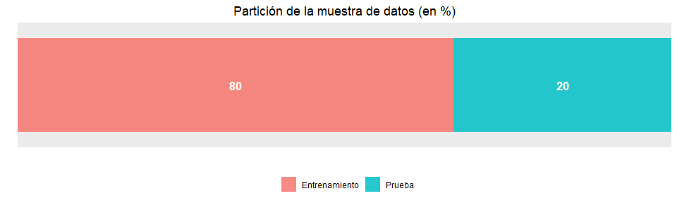

Siempre es importante tener en cuenta que un modelo que ajuste bien a los datos de entrenamiento no necesariamente va a proyectar bien fuera de la muestra. Un ajuste perfecto siempre puede obtenerse usando un modelo con una suficiente cantidad de parámetros. **Sobreajustar un modelo a los datos es tan malo como fallar en identificar patrones sistemáticos.** Si el modelo está sobreajustado a los datos puede suceder que estemos captando el componente aleatorio de la serie que no será el mismo cuando lo probemos en otra muestra. Esto va a dar lugar a un peor desempeño predictivo cuando salgamos de la muestra de entrenamiento.

Algunas autores describen el conjunto de prueba como el **conjunto de reserva** porque estos datos se excluyen de los datos utilizados para el ajuste. Otros autores llaman al conjunto de entrenamiento los **datos dentro de la muestra** y al conjunto de prueba los **datos fuera de la muestra**.

### Definición del error de proyección

El error de proyección es la diferencia entre el valor observado y su proyección. La palabra “error” hace referencia a la parte impredecible de cada observación.

Notar que los errores de proyección son diferentes en dos sentidos a los residuos:

$$\begin{align*}
𝑒_{𝑇+ℎ}=𝑦_{𝑇+ℎ}−\hat{𝑦}_{𝑇+h|T} \\
\end{align*}$$

- Los residuos son calculados sobre la muestra de entrenamiento, mientras que los errores de pronóstico son calculados sobre la muestra de prueba.
- Los residuos están basados en proyecciones un período hacia adelante, mientras que los errores de pronóstico pueden involucrar varios períodos hacia adelante.

### Métricas para evaluar la precisión de las proyecciones

Podemos medir la precisión de las proyecciones resumiendo los errores de pronóstico a partir del cálculo de las siguientes tres métricas:

**1. Mean Absolute Error: MAE**

$$\begin{align*}
𝑀𝐴𝐸=𝑚𝑒𝑎𝑛(|𝑒_𝑡 |) \\
\end{align*}$$

**2. Root Mean Squared Error: RMSE**

$$\begin{align*}
𝑅𝑀𝑆𝐸= \sqrt{𝑚𝑒𝑎𝑛(𝑒_{𝑡}^{2} ) } \\
\end{align*}$$

**3. Mean Absolute Percentage Error: MAPE**

$$\begin{align*}
𝑀𝐴𝑃𝐸=𝑚𝑒𝑎𝑛(|100\frac{𝑒_𝑡}{𝑦_𝑡} |) \\
\end{align*}$$

### ¿Qué métrica usar?

- **MAE**: se usa para una o varias series de tiempo con la misma escala. Un modelo de pronóstico que minimice el MAE conducirá a pronósticos de la mediana y por lo tanto será menos sensible a valores atípicos.
- **RMSE**: se usa para una o varias series de tiempo con la misma escala. Un modelo de pronóstico que minimice el RMSE conducirá a pronósticos de la media y será más sensible a los valores atípicos. Por este motivo puede ser útil para investigar la presencia y características de valores atípicos.
- **MAPE**: se usa para una o varias series de tiempo que pueden no tener la misma escala. También tiene desventajas: es indefinido o infinito cuando la variable es cero, o tiene valores extremos cuando está cercana a cero.

## Resumen conceptual

- Los **modelos VAR** son útiles cuando queremos proyectar una variable (o un conjunto de variables) cuyas explicativas no las podemos asumir como estrictamente exógenas, y debemos poder captar las relaciones de **causación mutua** entre ellas.
- En los modelos VAR más simples se trata de manera simétrica a todas las variables: se asume que todas son endógenas. Por este motivo es que son modelos desprovistos de teoría: no se realizan supuestos *ex ante* sobre cómo es que se relacionan las variables.
- Para evaluar qué tan preciso es un modelo para proyectar podemos calcular el **error de pronóstico** sobre un conjunto de datos que no fueron utilizados para ajustar los coeficientes del modelo (muestra de control).
- Con los errores de pronóstico luego podemos construir indicadores que nos permitan resumir la precisión predictiva de cada modelo para luego compararlos. Para modelos estimados sobre una misma variable o sobre variables con la misma escala podemos utilizar el **MAE** y el **RMSE**. Para el resto de los casos podemos utilizar el **MAPE**.

# Módulo práctico

## Paso 1. Limpiamos la memoria y cargamos las librerías

Para comenzar vamos a limpiar la memoria de R-studio con el código `rm(list=ls())`. Luego vamos a cargar un conjunto de librerías que utilizaremos en esta clase con el código `library()`. Si es la primera vez que usamos estas librerias tendremos que instalarlas con el código `install.packages()`.

```r
#  Limpiar la memoria

rm(list=ls())

# Instalamos librerías
#install.packages("vars")
#install.packages("zoo")
#install.packages("forecast")

# Apertura de librerias
library(tidyverse)
library(openxlsx)
library(lubridate)
library(zoo)
library(forecast)
library(ggfortify)
library(vars)
library(seasonal)
```

## Paso 2. Definimos el directorio y cargamos el archivo

Con el código `setwd()` definimos una carpeta desde donde queremos levantar los archivos para trabajar y adonde podremos guardar por default los archivos nuevos que generemos. Luego, con la función `read.xlsx()` levantamos el archivo de Excel con los datos. Dentro de esa función tenemos que especificar el nombre del archivo con su extensión (“Clase 4.xlsx) y el nombre de la hoja en donde se encuentran los datos que queremos levantar (sheet =”Base").

```r
# Establecemos directorio
setwd("C:/Users/mcherkasky/Google Drive/CEPAL/Curso series de tiempo/Clase 4")

# Levantamos archivo desde Excel
df <- read.xlsx("Clase 4.xlsx",sheet = "Base")
```

## Paso 3. Inspeccionamos los datos

Las estadísticas descriptivas de una serie se pueden obtener con la función `summary()`. Esta información la podemos guardar en una matriz `as.matrix()` y luego la podemos presentar en una tabla con la función `kable()`.

```r
# Guardamos el resumen de estadística descriptiva en una matriz
summary<-as.matrix(summary(df))

kable(summary, align=rep('c', 4), format.args = list(big.mark = ".")) %>%
  kable_styling(bootstrap_options = c("striped", "hover"), font_size = 14)
```

|  | Fecha | y | q | IPC | RIPTE | TCN |
| --- | --- | --- | --- | --- | --- | --- |
|  | Min. :38017 | Min. :2004 | Min. :1.000 | Min. : 93.51 | Min. : 1085 | Min. : 2.890 |
|  | 1st Qu.:39569 | 1st Qu.:2008 | 1st Qu.:1.000 | 1st Qu.: 166.77 | 1st Qu.: 2373 | 1st Qu.: 3.145 |
|  | Median :41122 | Median :2012 | Median :2.000 | Median : 384.11 | Median : 6486 | Median : 4.611 |
|  | Mean :41122 | Mean :2012 | Mean :2.478 | Mean : 971.42 | Mean :14570 | Mean :14.776 |
|  | 3rd Qu.:42675 | 3rd Qu.:2016 | 3rd Qu.:3.000 | 3rd Qu.:1263.90 | 3rd Qu.:20394 | 3rd Qu.:15.450 |
|  | Max. :44227 | Max. :2021 | Max. :4.000 | Max. :5350.13 | Max. :72068 | Max. :88.571 |

## Paso 4. Definimos la variable tiempo

```r
# Declaramos fecha y aclaramos el origen
df$Fecha<-yq(paste(df$y, df$q, sep="-"))
```

## Paso 5. Aplicamos transformaciones a las series

Una vez que tenemos la base con las variables con las que queremos trabajar vamos a usar la función `mutate()` para crear la diferencia logarítmica del tipo de cambio nominal (TCN), del nivel de precios (IPC) y de los salarios registrados (RIPTE).

```r
# Desestacionalizamos la serie de salarios
df$RIPTE<- seasadj(seas(ts(df[,"RIPTE"],start=2005,frequency=4), x11=""))

df$RIPTE<-as.numeric(df$RIPTE)

# Creamos variable en diferencia logarítmica
df<-df %>% mutate(dlTCN = log(TCN) - lag(log(TCN)),
                  dlIPC = log(IPC) - lag(log(IPC)),
                  dlRIPTE = log(RIPTE) - lag(log(RIPTE))) %>%
  filter(y>2004)
```

Si bien en la base de datos con la que venimos trabajando ya declaramos la variable fecha, las funciones para modelizar con las cuales trabajaremos nos pedirán que las variables tengan un formato de series de tiempo. Para crear series de tiempo debemos usar la función `ts()`. Esta función la podemos aplicar a variables o incluso a una base de datos entera. Notar que debemos especificar el período en el cual comienza la serie y su frecuencia. Este caso tomamos series que comienzan en el año 2005 y cuya frecuencia es trimestral.

```r
# Creamos series de tiempo
df<-ts(df, start=2005,frequency=4)
```

## Paso 6. Selección de cantidad de rezagos del VAR

Como paso previo a la estimación del modelo VAR vamos a realizar un test para evaluar cuál es la cantidad de rezagos óptima para incorporar. Para ello usamos la función `VARselect()` de la libería `vars`. Cuando hay mucha diferencia en el resultado de los rezagos sugeridos se puede realizar un test de Portmanteau de correlación serial sobre los residuos de la regresión a distintas alternativas hasta tanto encontremos la opción con menos rezagos y sin correlación serial. Para más detalle ver las referencias bibliográficas.

```r
# Realizamos test para seleccionar la cantidad de rezagos
VARselect(df[2:65,7:8], lag.max=8,
          type="const")[["selection"]]
```

```
## AIC(n)  HQ(n)  SC(n) FPE(n)
##      1      1      1      1
```

## Paso 7. Estimación del VAR

Luego vamos a estimar el modelo con la función `VAR()`, en la cual vamos a especificar la cantidad de rezagos (p=1) y el tipo de especificación (con constante). Con la función `summary()` vamos a obtener los principales resultados de la estimación.

```r
# Estimación de modelo VAR
var <- VAR(df[,7:8], p=1, type="const")

# Resultados de la estimación
summary(var)
```

```
##
## VAR Estimation Results:
## =========================
## Endogenous variables: dlTCN, dlIPC
## Deterministic variables: const
## Sample size: 64
## Log Likelihood: 263.036
## Roots of the characteristic polynomial:
## 0.6065 0.165
## Call:
## VAR(y = df[, 7:8], p = 1, type = "const")
##
##
## Estimation results for equation dlTCN:
## ======================================
## dlTCN = dlTCN.l1 + dlIPC.l1 + const
##
##          Estimate Std. Error t value Pr(>|t|)
## dlTCN.l1  0.33414    0.14463   2.310   0.0243 *
## dlIPC.l1  0.24751    0.37163   0.666   0.5079
## const     0.02104    0.02089   1.007   0.3179
## ---
## Signif. codes:  0 '***' 0.001 '**' 0.01 '*' 0.05 '.' 0.1 ' ' 1
##
##
## Residual standard error: 0.0667 on 61 degrees of freedom
## Multiple R-Squared: 0.1596,  Adjusted R-squared: 0.1321
## F-statistic: 5.793 on 2 and 61 DF,  p-value: 0.004973
##
##
## Estimation results for equation dlIPC:
## ======================================
## dlIPC = dlTCN.l1 + dlIPC.l1 + const
##
##          Estimate Std. Error t value Pr(>|t|)
## dlTCN.l1 0.186109   0.037753   4.930 6.65e-06 ***
## dlIPC.l1 0.437437   0.097005   4.509 3.01e-05 ***
## const    0.025870   0.005453   4.744 1.30e-05 ***
## ---
## Signif. codes:  0 '***' 0.001 '**' 0.01 '*' 0.05 '.' 0.1 ' ' 1
##
##
## Residual standard error: 0.01741 on 61 degrees of freedom
## Multiple R-Squared: 0.6391,  Adjusted R-squared: 0.6273
## F-statistic: 54.01 on 2 and 61 DF,  p-value: 3.168e-14
##
##
##
## Covariance matrix of residuals:
##           dlTCN     dlIPC
## dlTCN 0.0044487 0.0005766
## dlIPC 0.0005766 0.0003031
##
## Correlation matrix of residuals:
##        dlTCN  dlIPC
## dlTCN 1.0000 0.4965
## dlIPC 0.4965 1.0000
```

## Paso 8. Proyección

Con la función `forecast()` vamos a generar una proyección de las dos variables que estamos tomando y con la función `autoplot()` vamos a generar un gráfico con la proyección puntual y los intervalos de confianza (lo que se conoce como “fan chart”).

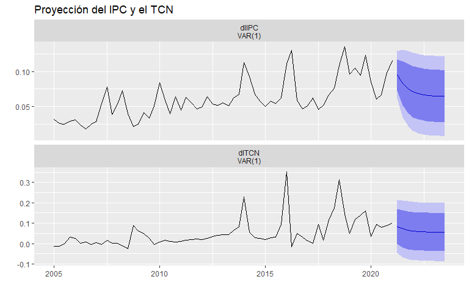

```r
# "Fan chart" de la proyección con el modelo VAR
forecast(var) %>%
  autoplot() +
  ggtitle("Proyección del IPC y el TCN") +
  labs(x = "", y = "")
```

También podemos graficar la función impulso-respuesta con la función `irf()`. En este caso introducimos un shock sobre el tipo de cambio nominal para ver la respuesta de la inflación. Notar que el primer valor es cero porque no hay efectos contemporáneos en ninguna de las ecuaciones.

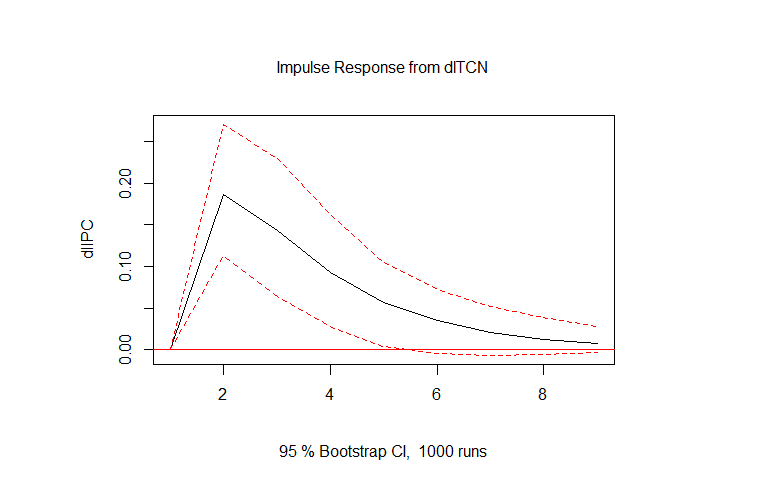

```r
# Función impulso-respuesta
feir <-irf(var, impulse = "dlTCN", response = "dlIPC",
             n.ahead = 8, ortho = FALSE, runs = 1000)

plot(feir )
```

## Paso 9. Partición de la muestra y estimación de los modelos

Primero vamos a dividir la muestra entre aquella que utilizaremos para estimar el modelo (“muestra de entrenamiento”) y aquella sobre la cual vamos a evaluar el grado de ajuste (“muestra de prueba”). La partición la hacemos con la función `window()`. Luego vamos a estimar dos modelos sobre la primera muestra: uno con dos variables y otro con tres. Por último, vamos a obtener la proyección de cada modelo para el período de prueba para luego calcular el ajuste.

```r
# Muestras de entrenamiento
df1<-window(df[,7:8], start=2006,end=c(2018,4))
df2<-window(df[,7:9], start=2006,end=c(2018,4))

# Muestra de prueba
IPC_test <- window(df[,8], start=2019,end=c(2019,4))

# Estimación del modelo sobre el conjunto de entrenamiento
var1 <- forecast(VAR(df1, p=1, type="const"),h=9)
var2 <- forecast(VAR(df2, p=1, type="const"),h=9)

# Proyección sobre el período correspondiente a la muestra de prueba
IPC_ajustado1<-var1$forecast$dlIPC$mean
IPC_ajustado2<-var2$forecast$dlIPC$mean
```

## Paso 10. Comparación de los modelos

En este paso vamos a utilizar las métricas para calcular el grado de ajuste de las estimaciones a los datos observados en la muestra de prueba, y vamos a comparar entre los dos modelos para ver cuál ajusta mejor. Nos interesa aquel modelo con el que obtengamos los menores valores de las métricas presentadas anteriormente (MAE, RMSE y MAPE).

```r
# Cálculo de métricas
a1<-accuracy(IPC_ajustado1, IPC_test)
a2<-accuracy(IPC_ajustado2, IPC_test)

# Armamos y presentamos una tabla con los resultados
comp<-rbind(a1,a2)
rownames(comp)[1] <- "Modelo 1"
rownames(comp)[2] <- "Modelo 2"

kable(comp, align=rep('c', 4), format.args = list(big.mark = ".")) %>%
  kable_styling(bootstrap_options = c("striped", "hover"), font_size = 14)
```

|  | ME | RMSE | MAE | MPE | MAPE | ACF1 | Theil’s U |
| --- | --- | --- | --- | --- | --- | --- | --- |
| Modelo 1 | 0.0211239 | 0.0314263 | 0.0264512 | 18.44181 | 23.98494 | 0.0204579 | 1.973543 |
| Modelo 2 | 0.0225220 | 0.0331169 | 0.0278264 | 19.72381 | 25.24308 | 0.0392985 | 2.081245 |

Por último, vamos a comparar el ajuste de los dos módelos en el siguiente gráfico.

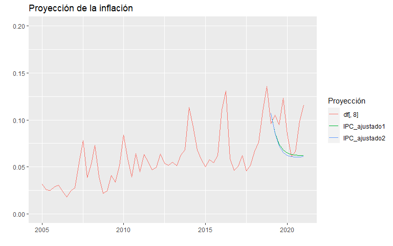

```r
autoplot(cbind(df[,8],IPC_ajustado1,IPC_ajustado2))+
  xlab("") + ylab("") +
  ylim(0,0.2)+
  ggtitle("Proyección de la inflación") +
  guides(colour=guide_legend(title="Proyección"))
```

# Referencias

- **Enders**, W. (2008). Applied econometric time series. John Wiley & Sons.
- **Hyndman**, R.J., & **Athanasopoulos**, G. (2018). Forecasting: principles and practice, 2nd edition, OTexts: Melbourne, Australia. OTexts.com/fpp2.
- **Wooldridge**, J. M. (2015). Introductory econometrics: A modern approach. Cengage learning.